# Week 5 Lecture

## What is ArcPy

- [What is arcpy](http://desktop.arcgis.com/en/arcmap/latest/analyze/arcpy/what-is-arcpy-.htm)
- `ArcPy` is a collection of modules, classes and functions which give access to all the geoprocessing tools in `ArcGIS` from within `Python`
- Most `geoprocessing` scripts will start with: **import arcpy**
- Note: `ArcPy` replaces the older `arcgisscripting` module

### Key features of arcpy

- Geoprocessing Tools: Provides access to hundreds of tools, such as buffers, spatial joins, and overlay operations.
- Automation: Automates repetitive GIS tasks, like updating feature classes or running models, which improves workflow efficiency.
- Spatial Analysis: Supports complex spatial operations like proximity analysis, surface analysis, and spatial statistics.
- Data Management: Handles the creation, manipulation, and conversion of spatial data formats (e.g., shapefiles, geodatabases).
- Map Production: Helps generate and modify maps by automating tasks such as adding layers, symbols, and exporting maps.

### Importing arcpy

- The ArcGIS Pro Conda environment is called arcgispro-py3 and is in the following folder `C:\Program Files\ArcGIS\Pro\bin\Python\envs`
- Select the Arcpy conda environment
- Using `import arcpy` import arcpy to your python environment

### Modules in arcpy

- The majority of `modules` represent an ArcGIS Pro toolbox that include variety of ArcGIS Pro tools.

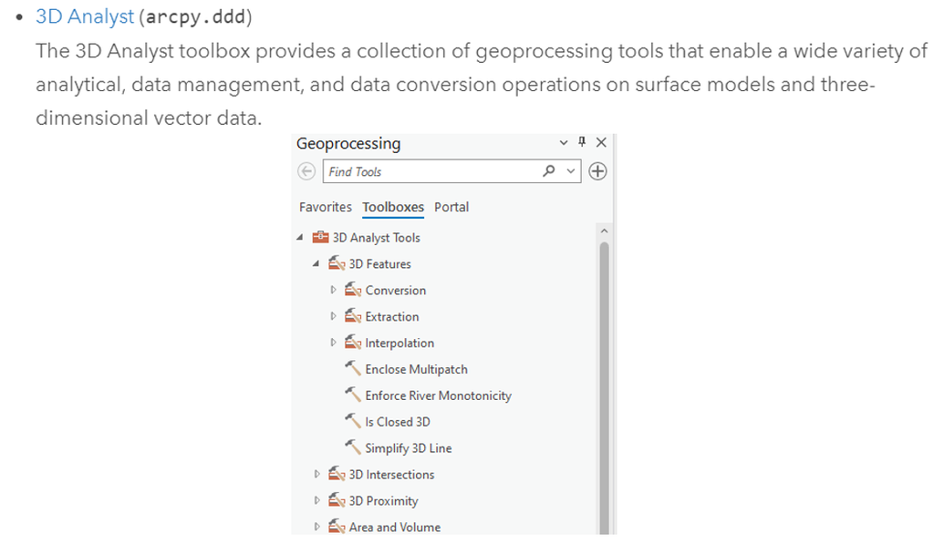

- For example, access [`Simplity 3D Line tool`](https://pro.arcgis.com/en/pro-app/latest/tool-reference/3d-analyst/simplify-3d-line.htm) using arcpy

```python
import arcpy.ddd
arcpy.ddd.Simplify3DLine()
```

import arcpy.ddd arcpy.ddd.Simplify3DLine()

### Classes in arcpy

- A `class` in Python is a blueprint for `creating objects (instances)`.
- Classes define objects with properties and methods that allow for more complex data structures or functions, such as layers, spatial references, or cursor objects for working with data.

For example, create Point object using [arcpy.Point](https://pro.arcgis.com/en/pro-app/latest/arcpy/classes/point.htm)

```python
pts = arcpy.Point(-71.8023, 42.2626)
```

pts = arcpy.Point(-71.8023, 42.2626)

### Functions in arcpy

- Definition: A function is a reusable piece of code that performs a specific task. Functions take inputs (arguments), perform operations, and return outputs.
- Purpose: Functions in arcpy perform specific geoprocessing tasks or operations on GIS data.
- Examples in arcpy:
  - `arcpy.Buffer_analysis()`: Creates a buffer around input features.

### Working with Layers

#### Determing the layer type and property

```python
import arcpy
import pandas as pd
```

import arcpy import pandas as pd

After importing `ArcPy`, start with **setting a workspace** to retrieve and store files.

```python
path_work = r'D:\OneDrive - Clark University\Clark_Python_Data\Week05_arcpy\zip_MA'
path_work = 'D:/OneDrive - Clark University/Clark_Python_Data\Week05_arcpy/zip_MA'
path_work = 'D:\\OneDrive - Clark University\\Clark_Python_Data\\Week05_arcpy\\zip_MA\\ZIP_ma.aprx'
```

path_work = r'D:\OneDrive - Clark University\Clark_Python_Data\Week05_arcpy\zip_MA' path_work = 'D:/OneDrive - Clark University/Clark_Python_Data\Week05_arcpy/zip_MA' path_work = 'D:\\OneDrive - Clark University\\Clark_Python_Data\\Week05_arcpy\\zip_MA\\ZIP_ma.aprx'

`arcpy.mp.ArcGISProject("path_work")` references the ArcGIS Pro project.

```python
aprx = arcpy.mp.ArcGISProject(path_work)
```

aprx = arcpy.mp.ArcGISProject(path_work)

`aprx.listMaps("Map")` iterates through maps from the project

`maps.listLayers()` retrieves a list of layers within a specific map.

`arcpy.Describe()` provides information about the layer object.

```python
for maps in aprx.listMaps("Map"):
    for lyr in maps.listLayers():
        desc = arcpy.Describe(lyr)
        print('{} is a {}'.format(desc.name, desc.dataType))
```

for maps in aprx.listMaps("Map"): for lyr in maps.listLayers(): desc = arcpy.Describe(lyr) print('{} is a {}'.format(desc.name, desc.dataType))

```
2024_Vehicle_Level_Crash_Details.shp is a FeatureLayer
zip_Worcester.shp is a FeatureLayer
```

```python
map = aprx.listMaps("Map")[0]
layer = map.listLayers()[0]
print(layer.name)
```

map = aprx.listMaps("Map")[0] layer = map.listLayers()[0] print(layer.name)

[output not shown]

#### Properties in layers

[Access to layer properties](https://pro.arcgis.com/en/pro-app/latest/arcpy/mapping/layer-class.htm)

```python
layer.isBasemapLayer
```

layer.isBasemapLayer

```
False
```

```python
###fina a way to plot layers
```

###fina a way to plot layers

### Symbology in Layer

- Symbology in GIS is the visual representation of spatial data, which helps in understanding and interpreting the information on maps.
- Symbology involves the styles and colors used to depict different features in a layer.
- Adjusting symbology can enhance map readability and convey specific patterns or trends.

```python
layer.symbology
```

layer.symbology

```
<arcpy._symbology.Symbology at 0x2565ec07a90>
```

```python
pd.DataFrame.spatial
```

pd.DataFrame.spatial